# HW 1

Richard Donald

September 2, 2020

## Question 1:

#### Produce a scatterplot between the Cost of Living Index and EACH of the other index variables. As aresult, there should be 4 scatterplots in total. Examine the relationship shown in each scatterplot in terms of its form,strength and direction.

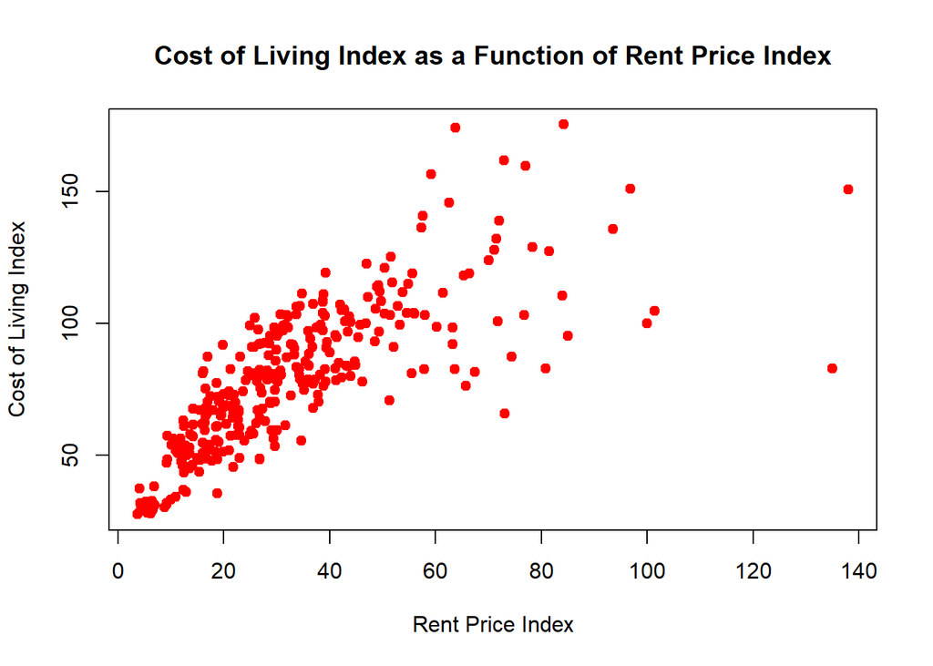

```r
plot(df$`Rent Index`, df$`Cost of Living Index`,
     pch = 19,  # solid circle
     col = 'red',
     main = "Cost of Living Index as a Function of Rent Price Index",
     xlab = "Rent Price Index",
     ylab = "Cost of Living Index")
```

> The Cost of Living Index as a Function of Rent Index has moderate strength, linear form, positive direction.

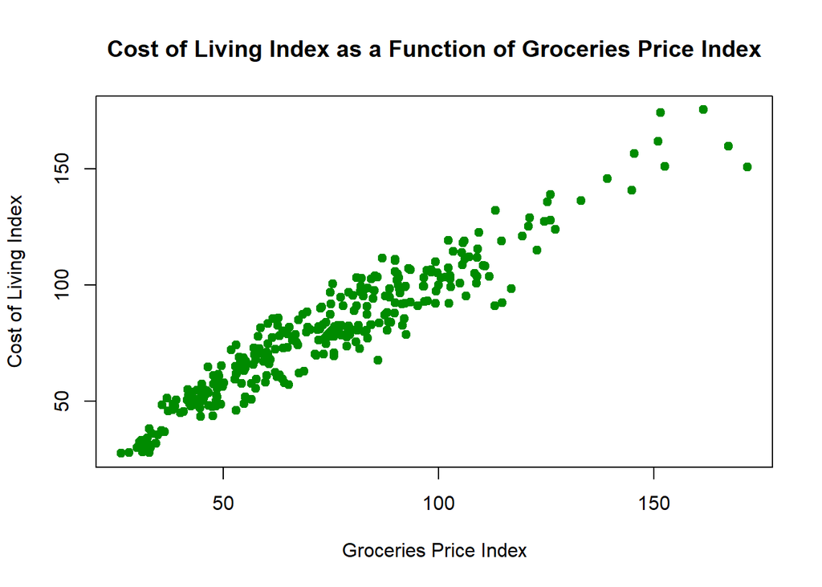

```r
plot(df$`Groceries Index`, df$`Cost of Living Index`,
     pch = 19,  # solid circle
     col = 'green4',
     main = "Cost of Living Index as a Function of Groceries Price Index",
     xlab = "Groceries Price Index",
     ylab = "Cost of Living Index")
```

> The Living Index as a Function of Groceries Price Index has high strength, linear form, positive direction.

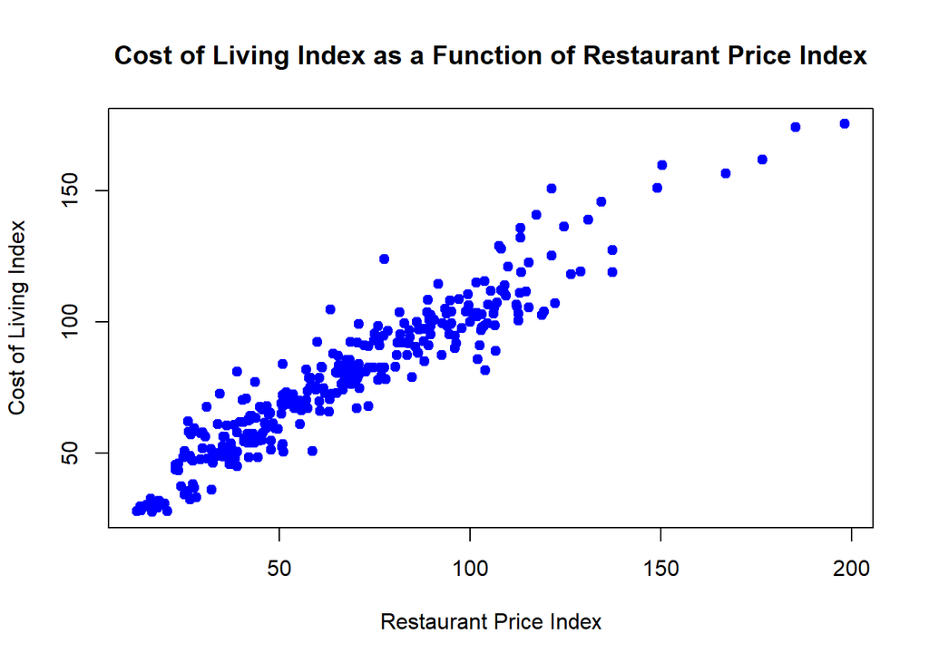

```r
plot(df$`Restaurant Price Index`, df$`Cost of Living Index`,
     pch = 19,  # solid circle
     col = 'blue',
     main = "Cost of Living Index as a Function of Restaurant Price Index",
     xlab = "Restaurant Price Index",
     ylab = "Cost of Living Index")
```

> The Cost of Living Index as a Function of Restaurant Price Index has high strength, linear form, positive direction.

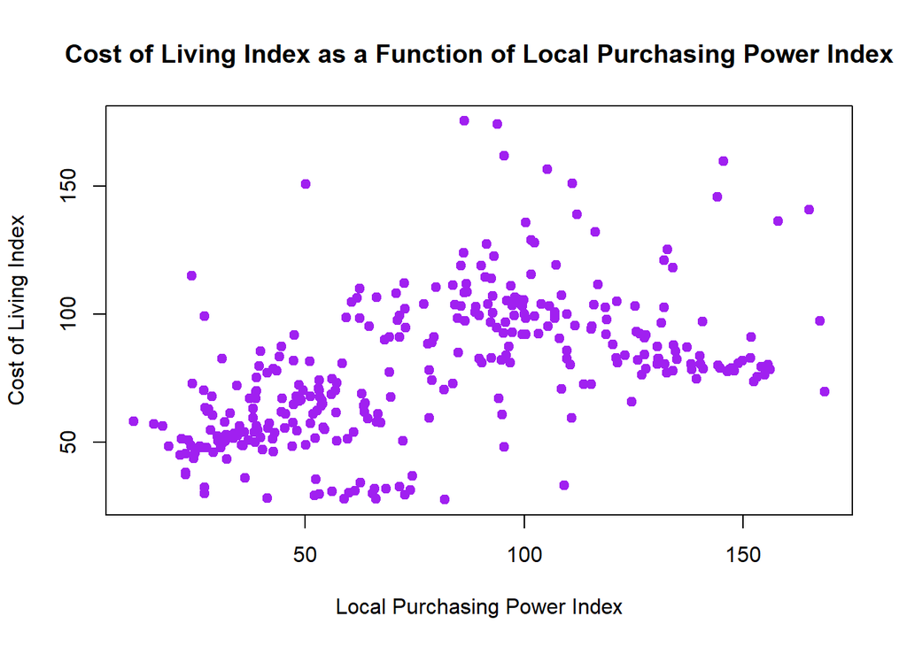

```r
plot(df$`Local Purchasing Power Index`, df$`Cost of Living Index`,
     pch = 19,  # solid circle
     col = 'purple',
     main = "Cost of Living Index as a Function of Local Purchasing Power Index",
     xlab = "Local Purchasing Power Index",
     ylab = "Cost of Living Index")
```

> The Cost of Living Index as a Function of Local Purchasing Power Index has low strength, linear form, positive direction.

## Question 2:

#### Compute the correlation coefficients for all the scatterplots obtained above.

```r
cor(df$`Rent Index`,df$`Cost of Living Index`)
```

```
## [1] 0.7722926
```

> Correlation coefficent(r) for Rent vs Cost of Living is 0.772

```r
cor(df$`Groceries Index`,df$`Cost of Living Index`)
```

```
## [1] 0.9538616
```

> Correlation coefficent(r) for Groceries vs Cost of Living is 0.954

```r
cor(df$`Restaurant Price Index`,df$`Cost of Living Index`)
```

```
## [1] 0.9493554
```

> Correlation coefficent(r) for Restaraunt Price vs Cost of Living is 0.949

```r
cor(df$`Local Purchasing Power Index`,df$`Cost of Living Index`)
```

```
## [1] 0.525902
```

> Correlation coefficent(r) for Local Purcharsing Power vs Cost of Living is 0.526

## Question 4:

#### Fit a linear regression model between the Cost of Living Index and each of the other index variables. As a result, there should be 4 regression models in total. Interpret the resulting estimated slope in each model.

```r
(m1 <- lm(df$`Cost of Living Index` ~ df$`Rent Index`))
```

```
##
## Call:
## lm(formula = df$`Cost of Living Index` ~ df$`Rent Index`)
##
## Coefficients:
##     (Intercept)  df$`Rent Index`
##          45.233            1.025
```

> The coefficient is 1.025, so we can expect a 1.025 % change in the Cost of Living Index for a 1% change in the Rent Index.

```r
(m2 <- lm(df$"Cost of Living Index" ~ df$"Groceries Index"))
```

```
##
## Call:
## lm(formula = df$"Cost of Living Index" ~ df$"Groceries Index")
##
## Coefficients:
##          (Intercept)  df$"Groceries Index"
##               9.2178                0.9529
```

> The coefficient is 0.953, so we can expect a 0.953 % change in the Cost of Living Index for a 1% change in the Groceries Price Index.

```r
(m3 <- lm(df$`Cost of Living Index` ~ df$`Restaurant Price Index`))
```

```
##
## Call:
## lm(formula = df$`Cost of Living Index` ~ df$`Restaurant Price Index`)
##
## Coefficients:
##                 (Intercept)  df$`Restaurant Price Index`
##                     24.6636                       0.8033
```

> The coefficient is 0.803, so we can expect a 0.803 % change in the Cost of Living Index for a 1% change in the Restaurant Price Index.

```r
(m4 <- lm(df$`Cost of Living Index` ~ df$`Local Purchasing Power Index`))
```

```
##
## Call:
## lm(formula = df$`Cost of Living Index` ~ df$`Local Purchasing Power Index`)
##
## Coefficients:
##                       (Intercept)  df$`Local Purchasing Power Index`
##                           48.9974                             0.3762
```

> The coefficient is 0.376, so we can expect a 0.376 % change in the Cost of Living Index for a 1% change in the Local Purchasing Power Index.

## Question 5:

#### Based on the correlation coefficients and the regression models obtained above, which item would be the best predictor of overall cost in these cities? Which would be the worst? Explain

Based off of these 4 models I would choose the Groceries Index vs. Living Index model because it has the highest correlation coefficient and it meets all the conditions.

The Local Purchasing Power vs. Cost of Living Index hs the lowest corelation coefficient so this would be the worst predictor of them all.

## Question 6:

#### Find the cost of living as predicted by Groceries Index and its residual for Beijing, China.

```r
# first need to find the index of "Beijing, China"
(df[df$City == "Beijing, China", ])
```

```
##               City Cost of Living Index Rent Index Groceries Index
## 172 Beijing, China                77.19      34.93           83.57
##     Restaurant Price Index Local Purchasing Power Index
## 172                  43.61                        41.35
```

```r
# then check the fitted value for that index location
(m2$fitted.values[172])
```

```
##      172
## 88.85556
```

> The observed value of the Cost of Living Index is 77.19, however, the predicted Cost of Living Index value using the model is 88.86

```r
(m2$residuals[172])
```

```
##       172
## -11.66556
```

> There is a - 11.67 residual. The model overestimated the value of the Cost of Living Index by 11.67%